# jekyll-jupyter-notebook20261007-3382-yimky8

```python
# Install necessary libraries (if not already present in Colab environment)
!pip install numpy pandas matplotlib seaborn scikit-learn
```

```python
# Import libraries
import numpy as np
import pandas as pd
import matplotlib.pyplot as plt
import seaborn as sns

# Scikit-learn for datasets, preprocessing, models, and metrics
from sklearn.datasets import make_classification, load_breast_cancer
from sklearn.model_selection import train_test_split
from sklearn.preprocessing import StandardScaler
from sklearn.linear_model import LogisticRegression
from sklearn.metrics import (
    accuracy_score, classification_report, confusion_matrix,
    roc_curve, roc_auc_score, precision_score, recall_score, f1_score
)

# Suppress warnings for cleaner output
import warnings
warnings.filterwarnings('ignore')

# Set a consistent plotting style
sns.set_theme(style="whitegrid")
```

### Part 1: Understanding Logistic Regression - The Basics

Logistic Regression is a statistical model used for **binary classification**, meaning it predicts one of two possible outcomes (e.g., Yes/No, True/False, 0/1). Unlike Linear Regression, which predicts a continuous value, Logistic Regression models the *probability* that a given input belongs to a certain class.

**1.1 The Problem It Solves:**

- Predicting a categorical outcome, specifically when there are only two categories.
- Examples: predicting if an email is spam (1) or not spam (0), if a customer will churn (1) or not (0), if a patient has a disease (1) or not (0).

**1.2 Differentiating from Linear Regression:**

- **Linear Regression output:** A continuous number (e.g., house price, temperature).
- **Logistic Regression output:** A probability (a value between 0 and 1). This probability is then converted into a class prediction based on a threshold (commonly 0.5).

**1.3 The Sigmoid (Logistic) Function:** The core of Logistic Regression is the **Sigmoid function** (also called the Logistic function). It takes any real-valued number and maps it into a value between 0 and 1.

The formula for the Sigmoid function is: $$\sigma(z) = \frac{1}{1 + e^{-z}}$$ Where $z$ is the output of a linear equation (similar to what we saw in Linear Regression).

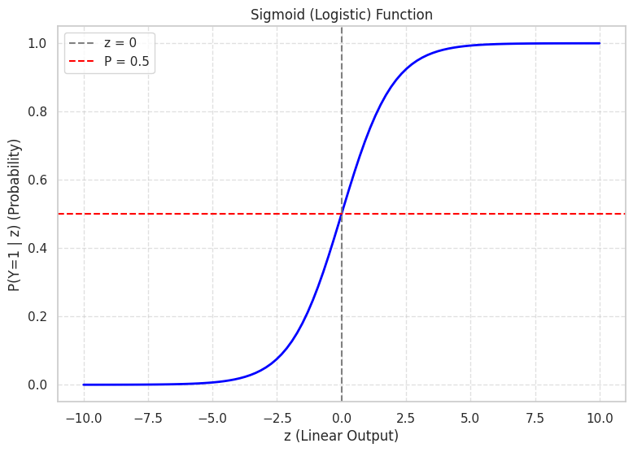

```python
# Define the sigmoid function
def sigmoid(z):
    return 1 / (1 + np.exp(-z))

# Generate a range of z values
z_values = np.linspace(-10, 10, 100)
# Calculate corresponding sigmoid values
sigmoid_values = sigmoid(z_values)

plt.figure(figsize=(9, 6))
plt.plot(z_values, sigmoid_values, color='blue', linewidth=2)
plt.axvline(0, color='gray', linestyle='--', label='z = 0')
plt.axhline(0.5, color='red', linestyle='--', label='P = 0.5')
plt.title('Sigmoid (Logistic) Function')
plt.xlabel('z (Linear Output)')
plt.ylabel('P(Y=1 | z) (Probability)')
plt.grid(True, linestyle='--', alpha=0.6)
plt.legend()
plt.show()
```

### **1.4 The Linear Combination:**

Before applying the sigmoid, Logistic Regression calculates a linear combination of its input features, just like Linear Regression:

$$ z = \beta_0 + \beta_1 x_1 + \beta_2 x_2 + \ldots + \beta_k x_k $$

Here, *z* can be any real number.

### **1.5 The Decision Boundary:**

Once the sigmoid function outputs a probability $P$, we need to convert it into a class prediction (0 or 1). This is done using a threshold.

The most common threshold is **0.5**:

- If $P(Y=1|z) \geq 0.5$, predict **Class 1** (Positive).
- If $P(Y=1|z) < 0.5$, predict **Class 0** (Negative).

The point where $P(Y=1|z) = 0.5$ (which corresponds to $z=0$) is the **decision boundary**.

> For a Logistic Regression model, this boundary is a straight line (or hyperplane in higher dimensions).

### **1.6 The Cost Function (Binary Cross-Entropy / Log Loss):**

Linear Regression uses Mean Squared Error (MSE) as its cost function. However, **MSE is not suitable for Logistic Regression** because the sigmoid function makes the cost function **non-convex**, which can cause gradient descent to get stuck in local minima.

Instead, Logistic Regression uses **Binary Cross-Entropy** (also known as **Log Loss**) as its cost function. This function penalizes confident wrong predictions heavily and encourages the model to output probabilities closer to the true labels.

$$ \text{Cost}(h_{\theta}(x), y) = -y \log(h_{\theta}(x)) - (1 - y) \log(1 - h_{\theta}(x)) $$

Where:

- $h_{\theta}(x)$ is the predicted probability,
- $y$ is the actual label (0 or 1).

The goal during training is to **find the coefficients ($\beta$ values) that minimize this cost function**, typically using an optimization algorithm like **Gradient Descent**.

**Discussion Point:**

- How does the Sigmoid function help transform the output of a linear model into a probability? What is the range of values it outputs?
- Why is a threshold (e.g., 0.5) necessary in Logistic Regression? What would happen if we used a different threshold, like 0.7?

### Part 2: Simple Logistic Regression with Scikit-learn (Synthetic Data)

Let's apply Logistic Regression to a simple 2D synthetic dataset to visualize the decision boundary.

**Tasks:**

- Create a 2D synthetic dataset with two separable classes.
- Visualize the data points.
- Train a `LogisticRegression` model.
- Plot the decision boundary learned by the model.
- Make predictions and observe probabilities.

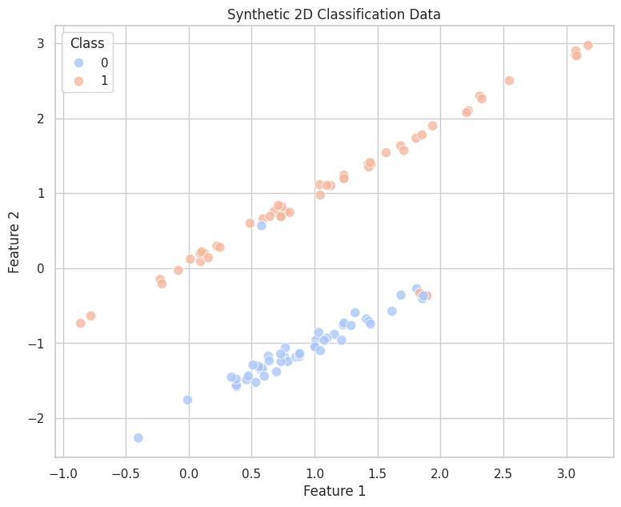

```python
# --- 2.1 Create a 2D synthetic dataset ---
# make_classification generates a random n-class classification problem.
# n_samples: total data points
# n_features: number of features (X dimensions)
# n_redundant: number of redundant features
# n_informative: number of informative features
# n_clusters_per_class: how many clusters per class
# random_state: for reproducibility
X_simple, y_simple = make_classification(n_samples=100, n_features=2, n_redundant=0,
                                       n_informative=2, n_clusters_per_class=1,
                                       random_state=42, flip_y=0.05) # Add a small amount of noise

# Convert to DataFrame for easier plotting
df_simple = pd.DataFrame(X_simple, columns=['Feature_1', 'Feature_2'])
df_simple['Target'] = y_simple

# --- 2.2 Visualize the data points ---
plt.figure(figsize=(9, 7))
sns.scatterplot(data=df_simple, x='Feature_1', y='Feature_2', hue='Target', palette='coolwarm', s=80, alpha=0.8)
plt.title('Synthetic 2D Classification Data')
plt.xlabel('Feature 1')
plt.ylabel('Feature 2')
plt.legend(title='Class')
plt.show()
```

```
Simple Logistic Regression model trained successfully!
```

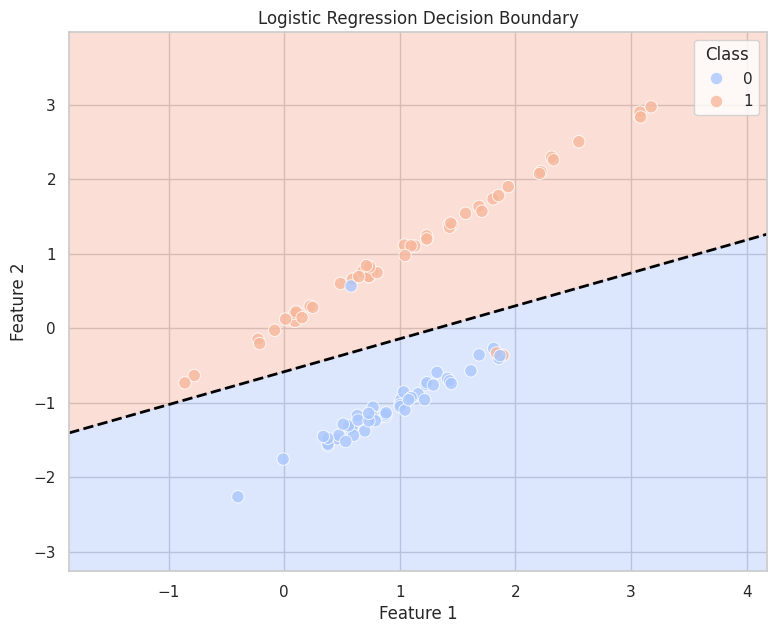

```python
# --- 2.3 Train a LogisticRegression model ---
model_simple_lr = LogisticRegression(random_state=42)
model_simple_lr.fit(X_simple, y_simple)

print("\nSimple Logistic Regression model trained successfully!")

# --- 2.4 Plot the decision boundary ---
# Create a meshgrid to plot the decision boundary
x_min, x_max = X_simple[:, 0].min() - 1, X_simple[:, 0].max() + 1
y_min, y_max = X_simple[:, 1].min() - 1, X_simple[:, 1].max() + 1
xx, yy = np.meshgrid(np.linspace(x_min, x_max, 100),
                     np.linspace(y_min, y_max, 100))

# Predict probabilities over the meshgrid
Z = model_simple_lr.predict_proba(np.c_[xx.ravel(), yy.ravel()])[:, 1] # Probability of Class 1
Z = Z.reshape(xx.shape)

plt.figure(figsize=(9, 7))
# Plot the contour lines of probabilities
plt.contourf(xx, yy, Z, levels=[0, 0.5, 1], cmap='coolwarm', alpha=0.3)
# Plot the decision boundary (where probability is 0.5)
plt.contour(xx, yy, Z, levels=[0.5], linewidths=2, colors='black', linestyles='--')
# Plot original data points
sns.scatterplot(data=df_simple, x='Feature_1', y='Feature_2', hue='Target', palette='coolwarm', s=80, alpha=0.8)

plt.title('Logistic Regression Decision Boundary')
plt.xlabel('Feature 1')
plt.ylabel('Feature 2')
plt.legend(title='Class')
plt.show()
```

```python
# --- 2.5 Make predictions and observe probabilities ---
sample_point_1 = np.array([0, 0]).reshape(1, -1) # A point near the center
sample_point_2 = np.array([1, 1]).reshape(1, -1) # A point in Class 1 region
sample_point_3 = np.array([-1, -1]).reshape(1, -1) # A point in Class 0 region

print(f"\nPrediction for {sample_point_1[0]}: Class {model_simple_lr.predict(sample_point_1)[0]}, Probabilities: {model_simple_lr.predict_proba(sample_point_1)[0]}")
print(f"Prediction for {sample_point_2[0]}: Class {model_simple_lr.predict(sample_point_2)[0]}, Probabilities: {model_simple_lr.predict_proba(sample_point_2)[0]}")
print(f"Prediction for {sample_point_3[0]}: Class {model_simple_lr.predict(sample_point_3)[0]}, Probabilities: {model_simple_lr.predict_proba(sample_point_3)[0]}")
```

```
Prediction for [0 0]: Class 1, Probabilities: [0.15725068 0.84274932]
Prediction for [1 1]: Class 1, Probabilities: [0.03624701 0.96375299]
Prediction for [-1 -1]: Class 1, Probabilities: [0.48071494 0.51928506]
```

**Discussion Point:**

- Observe the `predict_proba` output. What do the two numbers represent? How do they relate to the `predict` output?
- Why is the decision boundary a straight line in this 2D example? What would it look like with more features?

### Part 3: Multiple Logistic Regression (Real-world Data)

Now, let's apply Logistic Regression to a real-world dataset with multiple features. We'll use the Breast Cancer Wisconsin (Diagnostic) dataset, which aims to classify tumors as malignant (cancerous) or benign (non-cancerous) based on various cell nucleus measurements.

**Tasks:**

- Load the Breast Cancer dataset.
- Perform initial data exploration.
- Define features (X) and target (y).
- Split data into training and testing sets.
- Apply feature scaling.
- Train a `LogisticRegression` model.
- Make predictions (class labels) and prediction probabilities on the test set.

```python
# --- 3.1 Load the Breast Cancer dataset ---
cancer = load_breast_cancer()
X_cancer = pd.DataFrame(cancer.data, columns=cancer.feature_names)
y_cancer = pd.Series(cancer.target) # 0: malignant, 1: benign (sklearn convention)

print(f"\nDataset loaded. Number of features: {X_cancer.shape[1]}")
print(f"Target classes: {cancer.target_names} (0 for malignant, 1 for benign)")

# --- 3.2 Initial data exploration ---
print("\n--- X_cancer Head ---")
print(X_cancer.head())
print("\n--- X_cancer Info ---")
X_cancer.info()
print("\n--- X_cancer Description ---")
print(X_cancer.describe())

print("\n--- Target (y_cancer) Value Counts ---")
print(y_cancer.value_counts())
print(f"Maliganant (0): {y_cancer.value_counts()[0]} samples")
print(f"Benign (1): {y_cancer.value_counts()[1]} samples")

# --- 3.3 Define features (X) and target (y) (already done above) ---
# y_cancer = pd.Series(cancer.target)
```

```
Dataset loaded. Number of features: 30
Target classes: ['malignant' 'benign'] (0 for malignant, 1 for benign)

--- X_cancer Head ---
   mean radius  mean texture  mean perimeter  mean area  mean smoothness  \
0        17.99         10.38          122.80     1001.0          0.11840
1        20.57         17.77          132.90     1326.0          0.08474
2        19.69         21.25          130.00     1203.0          0.10960
3        11.42         20.38           77.58      386.1          0.14250
4        20.29         14.34          135.10     1297.0          0.10030

   mean compactness  mean concavity  mean concave points  mean symmetry  \
0           0.27760          0.3001              0.14710         0.2419
1           0.07864          0.0869              0.07017         0.1812
2           0.15990          0.1974              0.12790         0.2069
3           0.28390          0.2414              0.10520         0.2597
4           0.13280          0.1980              0.10430         0.1809

   mean fractal dimension  ...  worst radius  worst texture  worst perimeter  \
0                 0.07871  ...         25.38          17.33           184.60
1                 0.05667  ...         24.99          23.41           158.80
2                 0.05999  ...         23.57          25.53           152.50
3                 0.09744  ...         14.91          26.50            98.87
4                 0.05883  ...         22.54          16.67           152.20

   worst area  worst smoothness  worst compactness  worst concavity  \
0      2019.0            0.1622             0.6656           0.7119
1      1956.0            0.1238             0.1866           0.2416
2      1709.0            0.1444             0.4245           0.4504
3       567.7            0.2098             0.8663           0.6869
4      1575.0            0.1374             0.2050           0.4000

   worst concave points  worst symmetry  worst fractal dimension
0                0.2654          0.4601                  0.11890
1                0.1860          0.2750                  0.08902
2                0.2430          0.3613                  0.08758
3                0.2575          0.6638                  0.17300
4                0.1625          0.2364                  0.07678

[5 rows x 30 columns]
```

[output cut: 94 more lines]

```
std          0.061867                 0.018061
min          0.156500                 0.055040
25%          0.250400                 0.071460
50%          0.282200                 0.080040
75%          0.317900                 0.092080
max          0.663800                 0.207500

[8 rows x 30 columns]

--- Target (y_cancer) Value Counts ---
1    357
0    212
Name: count, dtype: int64
Maliganant (0): 212 samples
Benign (1): 357 samples
```

```python
# --- 3.4 Split data into training and testing sets ---
X_train, X_test, y_train, y_test = train_test_split(X_cancer, y_cancer, test_size=0.25, random_state=42, stratify=y_cancer)
# stratify=y_cancer ensures that the proportions of target classes are preserved in train and test sets.

print(f"\nTraining set X shape: {X_train.shape}, y shape: {y_train.shape}")
print(f"Testing set X shape: {X_test.shape}, y shape: {y_test.shape}")
```

```
Training set X shape: (426, 30), y shape: (426,)
Testing set X shape: (143, 30), y shape: (143,)
```

```python
# --- 3.5 Apply feature scaling ---
# StandardScaler is crucial for Logistic Regression as it uses optimization algorithms
# that are sensitive to the scale of features.
scaler = StandardScaler()
X_train_scaled = scaler.fit_transform(X_train)
X_test_scaled = scaler.transform(X_test)

print("\nFeatures scaled successfully.")
print(f"Example of scaled data (first row of X_train_scaled):\n{X_train_scaled[0]}")
```

```
Features scaled successfully.
Example of scaled data (first row of X_train_scaled):
[ 1.65909581e+00  2.17205449e-01  1.61061990e+00  1.63333853e+00
  5.76311605e-01  5.23544521e-01  6.45326310e-01  1.19874480e+00
 -9.35149071e-05 -1.24425088e-01  4.14312264e-01 -5.97142095e-01
  4.25167885e-01  4.97329621e-01 -6.44904409e-01 -1.38083245e-01
 -6.02764307e-02  1.97953779e-02 -1.15354241e+00 -1.48976771e-01
  1.56731877e+00 -7.58786987e-02  1.60722303e+00  1.38496870e+00
  4.12628434e-01  4.61628950e-01  6.42584428e-01  7.01834827e-01
 -5.56084149e-01  3.88780742e-01]
```

```python
# --- 3.6 Train a LogisticRegression model ---
model_multi_lr = LogisticRegression(random_state=42, max_iter=1000) # Increased max_iter for convergence
model_multi_lr.fit(X_train_scaled, y_train)

print("\nMultiple Logistic Regression model trained successfully!")
```

```
Multiple Logistic Regression model trained successfully!
```

```python
# --- 3.7 Make predictions and prediction probabilities on the test set ---
y_pred = model_multi_lr.predict(X_test_scaled)
y_pred_proba = model_multi_lr.predict_proba(X_test_scaled) # Probabilities for each class

print(f"\nFirst 5 true labels (test set): {y_test.tolist()[:5]}")
print(f"First 5 predicted labels: {y_pred.tolist()[:5]}")
print(f"First 5 predicted probabilities (Class 0, Class 1):\n{y_pred_proba[:5]}")
```

```
First 5 true labels (test set): [1, 0, 1, 1, 0]
First 5 predicted labels: [1, 0, 1, 1, 0]
First 5 predicted probabilities (Class 0, Class 1):
[[3.10179769e-02 9.68982023e-01]
 [9.99647982e-01 3.52018216e-04]
 [4.40588468e-01 5.59411532e-01]
 [6.10542466e-02 9.38945753e-01]
 [8.24508132e-01 1.75491868e-01]]
```

**Discussion Point:**

- Why is it particularly important to use `stratify=y_cancer` when splitting this dataset?
- Why is feature scaling (`StandardScaler`) crucial for Logistic Regression?

### Part 4: Model Evaluation for Classification

Evaluating classification models goes beyond simple accuracy, especially when classes are imbalanced or when the costs of different types of errors are unequal (e.g., misclassifying a malignant tumor as benign is more serious than the reverse).

### Accuracy

- **Formula:**  
  $ \frac{\text{Number of Correct Predictions}}{\text{Total Number of Predictions}} $
- **Interpretation:**  
  Overall proportion of correctly classified instances. Can be misleading for imbalanced datasets.

### Confusion Matrix

A table summarizing the performance of a classification algorithm.

|  | Predicted Negative (0) | Predicted Positive (1) |
| --- | --- | --- |
| **Actual Negative (0)** | True Negative (TN) | False Positive (FP) |
| **Actual Positive (1)** | False Negative (FN) | True Positive (TP) |

- **TP (True Positive):** Actual 1, Predicted 1
- **TN (True Negative):** Actual 0, Predicted 0
- **FP (False Positive):** Actual 0, Predicted 1 (Type I error)
- **FN (False Negative):** Actual 1, Predicted 0 (Type II error)

### Precision

- **Formula:**  
  $ \frac{TP}{TP + FP} $
- **Interpretation:**  
  Of all instances predicted as positive, what fraction were *truly* positive?  
  Relevant when the cost of a False Positive is high (e.g., wrongly flagging a healthy person with cancer).

### Recall (Sensitivity or True Positive Rate)

- **Formula:**  
  $ \frac{TP}{TP + FN} $
- **Interpretation:**  
  Of all actual positive instances, what fraction were predicted correctly?  
  Relevant when the cost of a False Negative is high (e.g., missing a cancer diagnosis).

### F1-Score

- **Formula:**  
  $ 2 \times \frac{\text{Precision} \times \text{Recall}}{\text{Precision} + \text{Recall}} $
- **Interpretation:**  
  Harmonic mean of precision and recall. Provides a single score that balances both precision and recall. Useful for imbalanced classes.

### ROC Curve & AUC (Area Under the Curve)

- **ROC Curve:**  
  Plots the True Positive Rate (Recall) against the False Positive Rate  
  ($ \frac{FP}{FP + TN} $) at various classification probability thresholds.  
  It illustrates the trade-off between sensitivity and specificity.
- **AUC (Area Under Curve):**  
  Measures the overall performance of a binary classifier, regardless of the classification threshold.
  - AUC = 1.0: Perfect classifier
  - AUC = 0.5: Random classifier (no better than flipping a coin)
  - AUC < 0.5: Worse than random (model is learning the wrong patterns)
- **Interpretation:**  
  A higher AUC indicates a better model. It represents the probability that the model will rank a randomly chosen positive instance higher than a randomly chosen negative instance.

### Tasks:

- Calculate Accuracy, Confusion Matrix, Precision, Recall, and F1-Score
- Generate and interpret the ROC Curve and AUC score

```
Accuracy: 0.9860

--- Confusion Matrix ---
[[52  1]
 [ 1 89]]
```

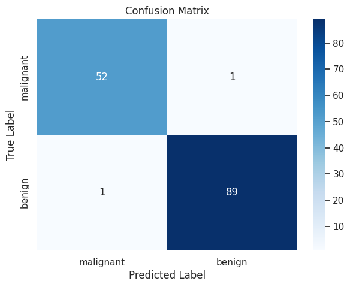

```
True Positives (TP): 89 (Correctly predicted benign)
True Negatives (TN): 52 (Correctly predicted malignant)
False Positives (FP): 1 (Actual malignant, Predicted benign - Type I error)
False Negatives (FN): 1 (Actual benign, Predicted malignant - Type II error)

--- Classification Report ---
              precision    recall  f1-score   support

   malignant       0.98      0.98      0.98        53
      benign       0.99      0.99      0.99        90

    accuracy                           0.99       143
   macro avg       0.99      0.99      0.99       143
weighted avg       0.99      0.99      0.99       143
```

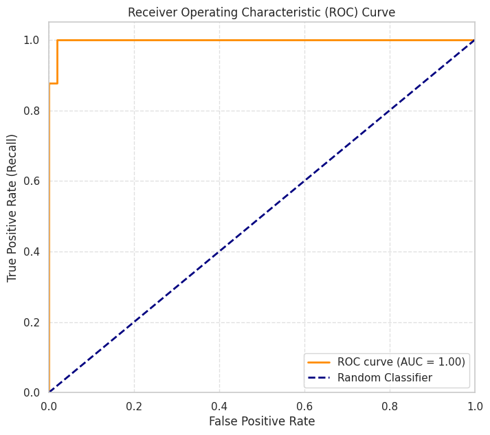

```python
from sklearn.metrics import (
    accuracy_score, confusion_matrix, classification_report,
    roc_curve, roc_auc_score
)
import matplotlib.pyplot as plt
import seaborn as sns

# --- 4.1 Accuracy Score ---
accuracy = accuracy_score(y_test, y_pred)
print(f"\nAccuracy: {accuracy:.4f}")

# --- 4.2 Confusion Matrix ---
cm = confusion_matrix(y_test, y_pred)
print("\n--- Confusion Matrix ---")
print(cm)

plt.figure(figsize=(7, 5))
sns.heatmap(cm, annot=True, fmt='d', cmap='Blues',
            xticklabels=cancer.target_names, yticklabels=cancer.target_names)
plt.title('Confusion Matrix')
plt.xlabel('Predicted Label')
plt.ylabel('True Label')
plt.show()

# Extracting values from confusion matrix for clarity
tn, fp, fn, tp = cm.ravel()
print(f"True Positives (TP): {tp} (Correctly predicted benign)")
print(f"True Negatives (TN): {tn} (Correctly predicted malignant)")
print(f"False Positives (FP): {fp} (Actual malignant, Predicted benign - Type I error)")
print(f"False Negatives (FN): {fn} (Actual benign, Predicted malignant - Type II error)")

# --- 4.3 Classification Report (Precision, Recall, F1-score) ---
print("\n--- Classification Report ---")
print(classification_report(y_test, y_pred, target_names=cancer.target_names))

# --- 4.4 ROC Curve and AUC ---
# y_pred_proba[:, 1] gives probabilities for class 1 ('benign')
fpr, tpr, thresholds = roc_curve(y_test, y_pred_proba[:, 1])
auc = roc_auc_score(y_test, y_pred_proba[:, 1])

plt.figure(figsize=(8, 7))
plt.plot(fpr, tpr, color='darkorange', lw=2, label=f'ROC curve (AUC = {auc:.2f})')
plt.plot([0, 1], [0, 1], color='navy', lw=2, linestyle='--', label='Random Classifier')
plt.xlim([0.0, 1.0])
plt.ylim([0.0, 1.05])
plt.xlabel('False Positive Rate')
plt.ylabel('True Positive Rate (Recall)')
plt.title('Receiver Operating Characteristic (ROC) Curve')
plt.legend(loc="lower right")
plt.grid(True, linestyle='--', alpha=0.6)
plt.show()
```

**Discussion Point:**

### Part 5: Interpretation of Coefficients & Decision Boundary

### Interpretation of Coefficients (Odds Ratios)

Unlike Linear Regression where coefficients directly represent the change in the target, in Logistic Regression, coefficients ($\beta_i$) represent the change in the **log-odds** of the dependent variable for a one-unit increase in the corresponding feature.

The **odds** of an event are defined as the ratio of the probability of the event occurring to the probability of it not occurring:
$$Odds = \frac{P(Y=1)}{1 - P(Y=1)}$$

The log-odds are simply $\log(\text{Odds})$.

To make coefficients more interpretable, we often convert them to **Odds Ratios** by exponentiating them:
$$Odds \text{ Ratio} = e^{\beta_i}$$

**Interpretation of Odds Ratio:**

- An odds ratio of 1.0 means the odds of the positive class do not change with a one-unit increase in the feature.
- An odds ratio greater than 1.0 means that for a one-unit increase in the feature, the odds of the positive class *increase* by `(Odds Ratio - 1) * 100%`, holding all other features constant.
- An odds ratio less than 1.0 means that for a one-unit increase in the feature, the odds of the positive class *decrease* by `(1 - Odds Ratio) * 100%`, holding all other features constant.

### Visualizing the Decision Boundary (for simple 2D case)

As seen in Part 2, the decision boundary of a Logistic Regression model is a straight line (or hyperplane in higher dimensions). This is because the core of the model is a linear combination of features ($z = \beta_0 + \beta_1 x_1 + \ldots + \beta_k x_k$), and the decision rule is when $z=0$ (which corresponds to probability = 0.5).

### Impact of `C` Parameter (Regularization)

`scikit-learn`'s `LogisticRegression` class includes a regularization parameter `C`.

- `C` is the inverse of regularization strength. Smaller values of `C` specify stronger regularization.
- Regularization helps prevent overfitting by penalizing large coefficients, effectively shrinking them towards zero. This makes the model simpler and less prone to capturing noise in the training data.
- A very large `C` implies very little regularization (similar to no regularization), which can lead to overfitting.
- A very small `C` implies strong regularization, which can lead to underfitting.

```python
# --- 5.1 Get coefficients and intercept from the trained model ---
coefficients = model_multi_lr.coef_[0]
intercept = model_multi_lr.intercept_[0]

# Display intercept
print(f"\nModel Intercept (log-odds when all features are 0): {intercept:.4f}")

# Display coefficients and odds ratios
print("\nModel Coefficients and Odds Ratios:")
print("{:<25} {:<15} {:<15}".format("Feature", "Coefficient", "Odds Ratio"))
print("-" * 55)

for i, feature_name in enumerate(cancer.feature_names):
    coef = coefficients[i]
    odds_ratio = np.exp(coef)
    print("{:<25} {:<15.4f} {:<15.4f}".format(feature_name, coef, odds_ratio))
```

```
Model Intercept (log-odds when all features are 0): 0.2806

Model Coefficients and Odds Ratios:
Feature                   Coefficient     Odds Ratio
-------------------------------------------------------
mean radius               -0.5231         0.5927
mean texture              -0.5187         0.5953
mean perimeter            -0.4837         0.6165
mean area                 -0.5573         0.5727
mean smoothness           -0.3010         0.7401
mean compactness          0.6942          2.0022
mean concavity            -0.5654         0.5681
mean concave points       -0.6769         0.5082
mean symmetry             -0.1262         0.8814
mean fractal dimension    0.0837          1.0873
radius error              -1.0701         0.3430
texture error             0.2607          1.2979
perimeter error           -0.4911         0.6120
area error                -0.9411         0.3902
smoothness error          -0.1456         0.8645
compactness error         0.6164          1.8523
concavity error           0.1541          1.1666
concave points error      -0.3440         0.7089
symmetry error            0.4251          1.5297
fractal dimension error   0.3749          1.4548
worst radius              -0.9175         0.3995
worst texture             -1.2501         0.2865
worst perimeter           -0.7212         0.4862
worst area                -0.9258         0.3962
worst smoothness          -0.6696         0.5119
worst compactness         0.0466          1.0477
worst concavity           -0.7968         0.4508
worst concave points      -0.9419         0.3899
worst symmetry            -0.9570         0.3840
worst fractal dimension   -0.2096         0.8109
```

### 5.2 Interpreting Odds Ratios (Example using Mean Radius)

If **'mean radius'** has an odds ratio of, say, **0.0125**, it means that for every one-unit increase in *mean radius* (after scaling), the **odds of the tumor being BENIGN (Class 1)** are reduced by:

$$ (1 - 0.0125) \times 100\% = 98.75\% $$ holding all other features constant.

This implies that a **larger 'mean radius'** is strongly associated with the **MALIGNANT class (Class 0)**.

### 5.3 Notes on Interpretation & Decision Boundary

- The interpretation above applies to **scaled features**.  
  For unscaled interpretation, you'd need to reverse the scaling transformation or understand the units of the original features — which can be more complex.
- **Visualizing the Decision Boundary (Revisiting Part 2 Concept):**  
  Recall from Part 2 that for a 2D dataset, Logistic Regression draws a **straight line** as its decision boundary.  
  This is because the decision rule is based on a **linear combination of features** where:

  $$ z = \beta_0 + \beta_1 x_1 + \ldots + \beta_k x_k = 0 $$

### Part 6: Advantages, Disadvantages, and Use Cases

Logistic Regression is a foundational algorithm in machine learning and statistics. Understanding its strengths and weaknesses helps in deciding when to use it.

**Advantages:**

1. **Outputs Probabilities:** Unlike some other classifiers that give only class labels, Logistic Regression provides probabilities (e.g., 85% chance of being benign). This is highly valuable for risk assessment, ranking, or when you need more nuance than a simple "yes/no" answer.
2. **Interpretable Coefficients:** As demonstrated with odds ratios, the coefficients can be interpreted to understand the direction and magnitude of the influence of each feature on the odds of the positive outcome. This provides insights into the underlying relationships in the data.
3. **Computationally Efficient:** It is relatively fast to train, especially compared to more complex models like Neural Networks or Ensemble methods. It scales well to large datasets.
4. **Well-Understood and Robust:** It has a strong statistical foundation and is less prone to overfitting than highly complex models on small to medium-sized datasets, especially when regularization is used.
5. **Good Baseline Model:** Often serves as an excellent starting point and a benchmark. If a more complex model doesn't significantly outperform Logistic Regression, it might not be worth the added complexity.

**Disadvantages:**

1. **Assumes Linearity (in the log-odds):** Logistic Regression assumes a linear relationship between the independent variables and the *log-odds* of the dependent variable. If the true relationship is highly non-linear, it may not perform well unless appropriate feature engineering (e.g., polynomial features, interaction terms) is applied.
2. **Sensitive to Outliers:** While less sensitive than OLS Linear Regression, extreme outliers can still disproportionately influence the model's coefficients and predictions.
3. **Does Not Handle High-Dimensional Data Well Natively:** For datasets with a very large number of features, especially if many are irrelevant, it can still suffer from overfitting without strong regularization. Feature selection or dimensionality reduction might be needed.
4. **Assumes Independence of Observations:** Like Linear Regression, it assumes that the observations are independent of each other. This can be problematic in time-series data or clustered data.
5. **Multicollinearity:** While it doesn't destabilize coefficients as severely as in OLS Linear Regression, high multicollinearity can still make the interpretation of individual feature coefficients less reliable (though overall predictive performance might not be heavily impacted).

**Common Use Cases:**

- **Spam Detection:** Classifying emails as "spam" or "not spam."
- **Medical Diagnosis:** Predicting the presence or absence of a disease (e.g., benign/malignant tumor, diabetic/non-diabetic).
- **Credit Scoring:** Assessing the likelihood of a loan applicant defaulting on a loan (e.g., "high risk" or "low risk").
- **Customer Churn Prediction:** Predicting whether a customer will stop using a service or product.
- **Marketing Response Prediction:** Identifying which customers are most likely to respond to a marketing campaign.
- **Election Prediction:** Predicting whether a candidate will win or lose an election based on demographics and polling data.

Prepared By

**Md. Atikuzzaman**  
Lecturer  
Department of Computer Science and Engineering  
Green University of Bangladesh  
Email: atik@cse.green.edu.bd